# hw4

# Information

**the Github website for this homework is https://github.com/jiayihu-Jeffery/stats506_hw4**

## Problem Set #04

## Problem 1 - Tidyverse: New Zealand

Use the **tidyverse** for this problem. In particular, use piping and **dplyr** as much as you are able. **Note**: Use of any deprecated functions will result in a point loss.

Install and load the package [**nzelect**](https://cran.r-project.org/package=nzelect). This package contains a number of data tables with information about election results in New Zealand. Use the `nzge` data for this problem.

Note that there are two types of votes cast - a Candidate vote, and a Party vote. Be sure to handle these separately as appropriate. Don’t forget that `help()` works on data as well a functions (assuming the data is appropriately documented).

1. Generate a table (which can just be a nicely printed tibble) of vote count (regardless of party) per year/type. Make sure to sort it by vote count.

```r
library(tidyverse)
library(nzelect)

votes_per_year_type <- nzelect::nzge %>%
group_by(election_year, voting_type) %>%
summarise(
total_votes = sum(votes, na.rm = TRUE)
) %>%
ungroup() %>%
arrange(desc(total_votes))
print(votes_per_year_type)
```

```
# A tibble: 10 × 3
   election_year voting_type total_votes
           <dbl> <chr>             <dbl>
 1          2014 Party           2416479
 2          2014 Candidate       2375493
 3          2008 Party           2356536
 4          2008 Candidate       2325598
 5          2005 Party           2286190
 6          2005 Candidate       2260670
 7          2011 Party           2257336
 8          2011 Candidate       2225766
 9          2002 Party           2040248
10          2002 Candidate       2022115
```

2. Focus only on the 2014 election. Report the proportion of votes for each party in the Candidate election. Again, produce a nice table and sort it by percent of vote.

```r
prop_2014_candidate <- nzelect::nzge %>%
filter(election_year == 2014) %>%
filter(voting_type == "Candidate") %>%
group_by(party) %>%
summarise(
party_votes = sum(votes, na.rm = TRUE)
) %>%
ungroup() %>%
mutate(
proportion = party_votes / sum(party_votes),
percentage = scales::percent(proportion, accuracy = 0.01)
) %>%
arrange(desc(proportion))

print(prop_2014_candidate)
```

```
# A tibble: 25 × 4
   party                    party_votes proportion percentage
   <chr>                          <dbl>      <dbl> <chr>
 1 National Party               1081787    0.455   45.54%
 2 Labour Party                  801287    0.337   33.73%
 3 Green Party                   165718    0.0698  6.98%
 4 Conservative Party             81075    0.0341  3.41%
 5 New Zealand First Party        73384    0.0309  3.09%
 6 Maori Party                    42108    0.0177  1.77%
 7 MANA Movement                  32333    0.0136  1.36%
 8 Informal Candidate Votes       27886    0.0117  1.17%
 9 ACT New Zealand                27778    0.0117  1.17%
10 United Future                  14722    0.00620 0.62%
# ℹ 15 more rows
```

3. Produce a nice table indicating, for each year, which party won the Candidate vote and which party won the Party vote.

```r
winning_parties_per_year <- nzelect::nzge %>%
group_by(election_year, voting_type, party) %>%
summarise(
total_party_votes = sum(votes, na.rm = TRUE),
.groups = 'drop'
) %>%
group_by(election_year, voting_type) %>%
slice_max(
order_by = total_party_votes,
n = 1,
with_ties = FALSE
) %>%
select(election_year, voting_type, party) %>%
ungroup() %>%
pivot_wider(
names_from = voting_type,
values_from = party
) %>%
arrange(desc(election_year))

print(winning_parties_per_year)
```

```
# A tibble: 5 × 3
  election_year Candidate      Party
          <dbl> <chr>          <chr>
1          2014 National Party National Party
2          2011 National Party National Party
3          2008 National Party National Party
4          2005 National Party Labour Party
5          2002 Labour Party   Labour Party
```

## Problem 2 - Tidyverse: Tennis

Use the **tidyverse** for this problem. In particular, use piping and **dplyr** as much as you are able. **Note**: Use of any deprecated functions will result in a point loss.

Use the “ATP Matches” data from 2019 available at https://raw.githubusercontent.com/JeffSackmann/tennis_atp/refs/heads/master/atp_matches_2019.csv. This data tracks all Tennis matches. This data does *not* have documentation, so you’ll have to explore the data yourself to figure out it’s structure. Use it to answer the following questions. Your answers should show both the output from R that allows you to answer it, as well as a written answer.

1. How many tournaments took place in 2019?

```r
library(tidyverse)

# Tennis 2019
atp_matches_2019 <- read_csv("https://raw.githubusercontent.com/JeffSackmann/tennis_atp/refs/heads/master/atp_matches_2019.csv")

# head(atp_matches_2019)

atp_matches_2019 %>%
  summarize(num_tournaments = n_distinct(tourney_id))
```

```
# A tibble: 1 × 1
  num_tournaments
            <int>
1             128
```

2. Did any player win more than one tournament? If so, how many players won more than one tournament, and how many tournaments did the most winning player(s) win?

```r
champions_summary <- atp_matches_2019 %>%
  filter(round == "F") %>%
  group_by(winner_name) %>%
  summarize(championships_won = n()) %>%
  arrange(desc(championships_won))

print(champions_summary)
```

```
# A tibble: 41 × 2
   winner_name        championships_won
   <chr>                          <int>
 1 Dominic Thiem                      5
 2 Novak Djokovic                     5
 3 Daniil Medvedev                    4
 4 Rafael Nadal                       4
 5 Roger Federer                      4
 6 Alex De Minaur                     3
 7 Stefanos Tsitsipas                 3
 8 Benoit Paire                       2
 9 Cristian Garin                     2
10 Jo-Wilfried Tsonga                 2
# ℹ 31 more rows
```

```r
# Count how many players won more than one tournament
players_with_multiple_wins <- champions_summary %>%
  filter(championships_won > 1) %>%
  summarize(num_players = n())

print(players_with_multiple_wins)
```

```
# A tibble: 1 × 1
  num_players
        <int>
1          12
```

3. Is there any evidence that winners have more aces than losers? (If you address this with a hypothesis test, do not use base R functionality - continue to remain in the Tidyverse.)

```r
# (1) Paired differences (winner ACE − loser ACE)

ace_diff <- atp_matches_2019 %>%
transmute(ace_diff = w_ace - l_ace) %>%
tidyr::drop_na(ace_diff)

# (2) Sample stats and effect size

ace_stats <- ace_diff %>%
summarise(
n = n(),
mean_diff = mean(ace_diff),
sd_diff = sd(ace_diff),
cohen_d = mean_diff / sd_diff
)

# (3) One-sided paired t-test (H1: mean_diff > 0)

ace_test <- ace_diff %>%
t_test(response = ace_diff, mu = 0, alternative = "greater")

# (4) Tidy summary table

ace_tidy <- ace_stats %>%
bind_cols(
ace_test %>%
select(
t = statistic, df = t_df, p_value,
estimate, lower_ci
)
) %>%
rename(mean_diff_est = estimate, ci_lower = lower_ci)

# (5) Print tidy table

ace_tidy
```

```
# A tibble: 1 × 9
      n mean_diff sd_diff cohen_d     t    df  p_value mean_diff_est ci_lower
  <int>     <dbl>   <dbl>   <dbl> <dbl> <dbl>    <dbl>         <dbl>    <dbl>
1  2694      1.70    7.15   0.238  12.4  2693 1.53e-34          1.70     1.48
```

```r
# (6) Text conclusion

cat(
  glue(
    "Conclusion (one-sided paired t-test): On average, winners serve {round(ace_tidy$mean_diff_est, 2)} more aces than losers; ",
    "t = {round(ace_tidy$t, 2)}, df = {ace_tidy$df}, p = {format(ace_tidy$p_value, digits = 3)}; ",
    "95% CI lower bound for the mean difference = {round(ace_tidy$ci_lower, 2)}; ",
    "Cohen's d (for paired differences) = {round(ace_tidy$cohen_d, 2)}.\n",
    "Therefore, there is strong evidence that winners serve significantly more aces."
  )
)
```

```
Conclusion (one-sided paired t-test): On average, winners serve 1.7 more aces than losers; t = 12.37, df = 2693, p = 1.53e-34; 95% CI lower bound for the mean difference = 1.48; Cohen's d (for paired differences) = 0.24.
Therefore, there is strong evidence that winners serve significantly more aces.
```

4. Identify the player(s) with the highest win-rate. (Note that this is NOT asking for the highest number of wins.) Restrict to players with at least 5 matches.

```r
# Highest win-rate with ≥ 5 matches — self-contained chunk

win_rate_summary <- atp_matches_2019 %>%
  select(winner_name, loser_name) %>%
  pivot_longer(c(winner_name, loser_name),
               names_to = "result", values_to = "player_name") %>%
  mutate(win = if_else(result == "winner_name", 1L, 0L)) %>%
  group_by(player_name) %>%
  summarise(
    matches_played = n(),
    wins = sum(win),
    win_rate = wins / matches_played,
    .groups = "drop"
  ) %>%
  filter(matches_played >= 5) %>%
  arrange(desc(win_rate), desc(wins), player_name)

top_players <- win_rate_summary %>%
  slice_max(win_rate, with_ties = TRUE)

top_players_pretty <- top_players %>%
  mutate(
    win_rate = percent(win_rate),
    summary = paste0(player_name, " (", wins, "/", matches_played, ", ", win_rate, ")")
  )

top_players_pretty
```

```
# A tibble: 1 × 5
  player_name  matches_played  wins win_rate summary
  <chr>                 <int> <int> <chr>    <chr>
1 Rafael Nadal             69    60 87%      Rafael Nadal (60/69, 87%)
```

```r
# Text conclusion

cat(
  glue(
    "Under the restriction of at least 5 matches, the highest win rate is {top_players_pretty$win_rate[1]}, ",
    "achieved by: {paste(top_players_pretty$summary, collapse = '; ')}."
  )
)
```

```
Under the restriction of at least 5 matches, the highest win rate is 87%, achieved by: Rafael Nadal (60/69, 87%).
```

## Problem 3 - Visualization

Note: This is, intentionally, a very open-ended question. There is no “right” answer. The goal is for you to explore your plotting options, and settle on something reasonable. You can use base R, ggplot, or something else. You’ll likely have to look online for resources on plotting beyond what we covered in class.

Use the NYTimes Covid data (https://raw.githubusercontent.com/nytimes/covid-19-data/refs/heads/master/rolling-averages/us-states.csv). This lists daily Covid new cases. For each of the following, produce a publication-ready plot which addresses the question. Use your plot to support an argument for your question.

1. How many major and minor spikes in cases were there?

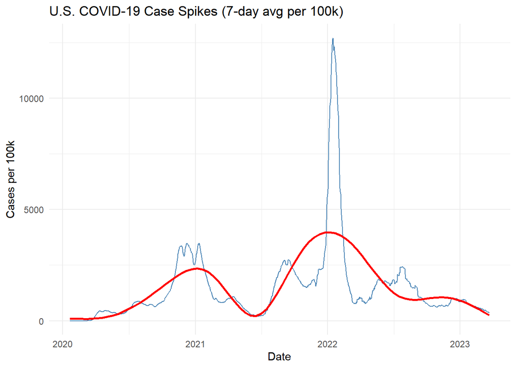

```r
library(tidyverse)

covid <- read_csv("https://raw.githubusercontent.com/nytimes/covid-19-data/refs/heads/master/rolling-averages/us-states.csv")
# National total per day (7-day avg) — currently summing per 100k; keep structure as given

us_cases <- covid %>%
group_by(date) %>%
summarise(total_cases = sum(cases_avg_per_100k, na.rm = TRUE))

ggplot(us_cases, aes(x = date, y = total_cases)) +
geom_line(color = "steelblue") +
geom_smooth(span = 0.2, color = "red", se = FALSE) +
labs(title = "U.S. COVID-19 Case Spikes (7-day avg per 100k)",
y = "Cases per 100k", x = "Date") +
theme_minimal()
```

2. For the states with the highest and lowest overall rates per population, what differences do you see in their trajectories over time?

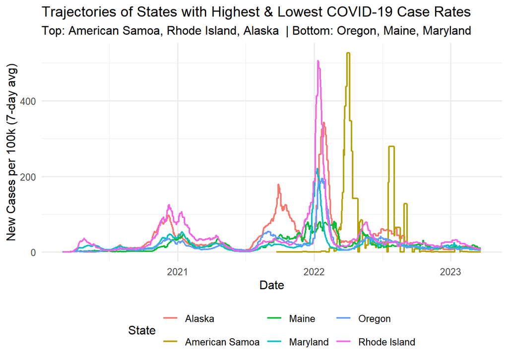

```r
library(tidyverse)

# Average rate (per 100k) by state

state_avg <- covid %>%
group_by(state) %>%
summarise(avg_rate = mean(cases_avg_per_100k, na.rm = TRUE)) %>%
arrange(desc(avg_rate))

# Top 3 and bottom 3 states

top_states <- head(state_avg$state, 3)
bottom_states <- tail(state_avg$state, 3)

# Plot trajectories

covid %>%
filter(state %in% c(top_states, bottom_states)) %>%
ggplot(aes(x = date, y = cases_avg_per_100k, color = state)) +
geom_line(linewidth = 0.8) +
labs(
title = "Trajectories of States with Highest & Lowest COVID-19 Case Rates",
subtitle = paste("Top:", paste(top_states, collapse = ", "),
" | Bottom:", paste(bottom_states, collapse = ", ")),
x = "Date",
y = "New Cases per 100k (7-day avg)",
color = "State"
) +
theme_minimal(base_size = 12) +
theme(legend.position = "bottom")
```

3. Identify, to the best of your ability without a formal test, the first five states to experience Covid in a substantial way.

```r
# Threshold to indicate "substantial outbreak" (e.g., ≥ 5 per 100k, 7-day avg)

first_substantial <- covid %>%
filter(cases_avg_per_100k >= 5) %>%
group_by(state) %>%
summarise(first_date = min(date)) %>%
arrange(first_date)

# First five states

head(first_substantial, 5)
```

```
# A tibble: 5 × 2
  state         first_date
  <chr>         <date>
1 New York      2020-03-21
2 New Jersey    2020-03-24
3 Louisiana     2020-03-26
4 Massachusetts 2020-03-27
5 Connecticut   2020-03-28
```

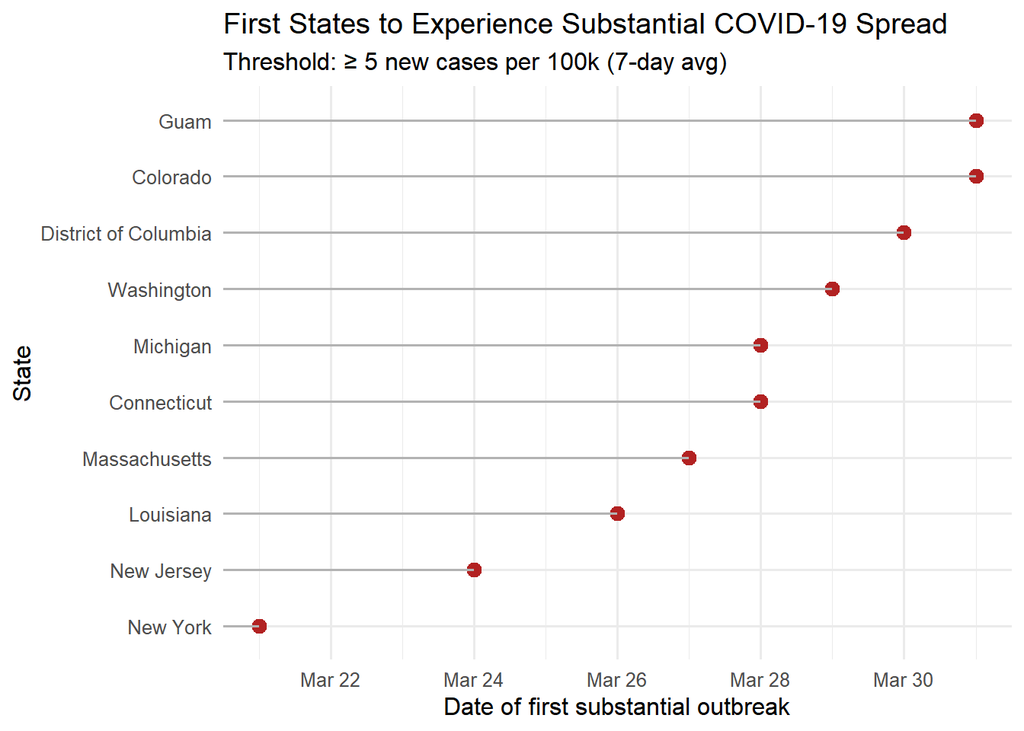

```r
# Timeline for the first 10 states

first_substantial %>%
slice_head(n = 10) %>%
ggplot(aes(x = first_date, y = reorder(state, first_date))) +
geom_point(color = "firebrick", size = 3) +
geom_segment(aes(xend = first_date, yend = state),
x = as.Date("2020-01-15"), color = "grey70") +
labs(
title = "First States to Experience Substantial COVID-19 Spread",
subtitle = "Threshold: ≥ 5 new cases per 100k (7-day avg)",
x = "Date of first substantial outbreak",
y = "State"
) +
theme_minimal(base_size = 12)
```